# Script-4.R

Usuario

Ramon

2025-08-28

```r
# Script 4
# 28/8/2025
# Ramón Copado García

# Importar

calidad <- read.csv("calidad_plantula.csv", header = T)
View(calidad)
calidad$Tratamiento <- as.factor(calidad$Tratamiento)
class(calidad$Tratamiento)
```

```
## [1] "factor"
```

```r
summary(calidad)
```

```
##      planta            IE         Tratamiento
##  Min.   : 1.00   Min.   :0.5500   Ctrl:21
##  1st Qu.:11.25   1st Qu.:0.7025   Fert:21
##  Median :21.50   Median :0.7950
##  Mean   :21.50   Mean   :0.8371
##  3rd Qu.:31.75   3rd Qu.:0.9375
##  Max.   :42.00   Max.   :1.1600
```

```r
mean(calidad$IE)
```

```
## [1] 0.8371429
```

```r
tapply(calidad$IE, calidad$Tratamiento, mean)
```

```
##      Ctrl      Fert
## 0.7676190 0.9066667
```

```r
tapply(calidad$IE, calidad$Tratamiento, sd)
```

```
##      Ctrl      Fert
## 0.1153215 0.1799537
```

```r
tapply(calidad$IE, calidad$Tratamiento, var)
```

```
##       Ctrl       Fert
## 0.01329905 0.03238333
```

```r
colores <-c ("navajowhite", "salmon")

# Crear un boxplot calidad
boxplot (calidad$IE~ calidad$Tratamiento, col = colores,
main = "Efecto de Fertilizante",
xlab = "Tratamiento",
ylab = "Indice de esbeltez",
ylim = c(0.4,1.2))
```

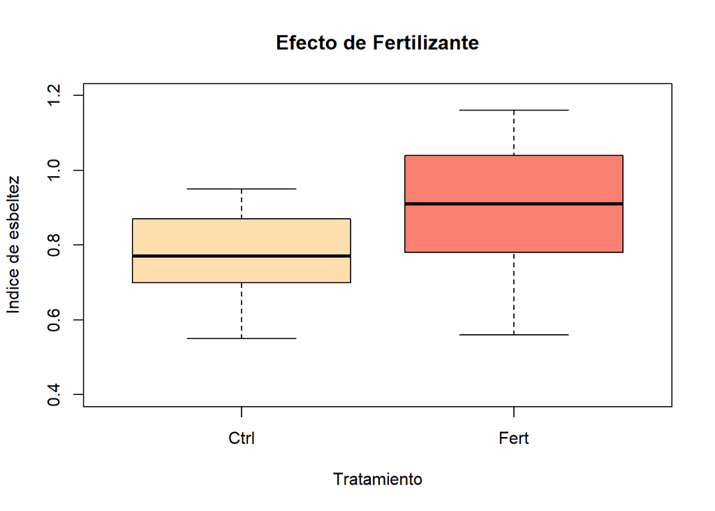

[figure not shown]

[figure not shown]

[figure not shown]

```r
# Observar datos
# Aplicar subconjunto para cada tratamiento

df_ctrl <- subset(calidad, Tratamiento == "Ctrl")
df_fert <- subset(calidad, Tratamiento == "Fert")

par(mfrow=c(1,2))
qqnorm(df_ctrl$IE); qqline(df_ctrl$IE)
qqnorm(df_fert$IE); qqline(df_fert$IE)
```

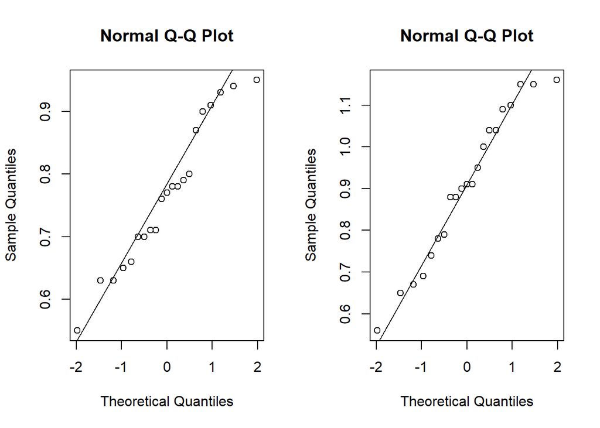

[figure not shown]

[figure not shown]

[figure not shown]

```r
par(mfrow=c(1,1))

# Prueba normalidad SHAPIRO.TEST
shapiro.test(df_ctrl$IE)
```

```
##
##  Shapiro-Wilk normality test
##
## data:  df_ctrl$IE
## W = 0.9532, p-value = 0.3908
```

```r
shapiro.test(df_fert$IE)
```

```
##
##  Shapiro-Wilk normality test
##
## data:  df_fert$IE
## W = 0.95339, p-value = 0.3941
```

```r
# Revisar homogeneidad
var.test(calidad$IE ~ calidad$Tratamiento)
```

```
##
##  F test to compare two variances
##
## data:  calidad$IE by calidad$Tratamiento
## F = 0.41068, num df = 20, denom df = 20, p-value = 0.05304
## alternative hypothesis: true ratio of variances is not equal to 1
## 95 percent confidence interval:
##  0.1666376 1.0121038
## sample estimates:
## ratio of variances
##          0.4106757
```

```r
# Prueba de T

t.test(calidad$IE ~ calidad$Tratamiento, alternative = "two.sided", var.equal = T)
```

```
##
##  Two Sample t-test
##
## data:  calidad$IE by calidad$Tratamiento
## t = -2.9813, df = 40, p-value = 0.004868
## alternative hypothesis: true difference in means between group Ctrl and group Fert is not equal to 0
## 95 percent confidence interval:
##  -0.23331192 -0.04478332
## sample estimates:
## mean in group Ctrl mean in group Fert
##          0.7676190          0.9066667
```

```r
t.test(calidad$IE ~ calidad$Tratamiento, alternative = "two.sided", var.equal = F)
```

```
##
##  Welch Two Sample t-test
##
## data:  calidad$IE by calidad$Tratamiento
## t = -2.9813, df = 34.056, p-value = 0.00527
## alternative hypothesis: true difference in means between group Ctrl and group Fert is not equal to 0
## 95 percent confidence interval:
##  -0.23382707 -0.04426816
## sample estimates:
## mean in group Ctrl mean in group Fert
##          0.7676190          0.9066667
```

```r
# Error estadistico de como plantear la pregunta
t.test(calidad$IE ~ calidad$Tratamiento, alternative = "greater", var.equal = T)
```

```
##
##  Two Sample t-test
##
## data:  calidad$IE by calidad$Tratamiento
## t = -2.9813, df = 40, p-value = 0.9976
## alternative hypothesis: true difference in means between group Ctrl and group Fert is greater than 0
## 95 percent confidence interval:
##  -0.2175835        Inf
## sample estimates:
## mean in group Ctrl mean in group Fert
##          0.7676190          0.9066667
```

```r
t.test(calidad$IE ~ calidad$Tratamiento, alternative = "greater", var.equal = F)
```

```
##
##  Welch Two Sample t-test
##
## data:  calidad$IE by calidad$Tratamiento
## t = -2.9813, df = 34.056, p-value = 0.9974
## alternative hypothesis: true difference in means between group Ctrl and group Fert is greater than 0
## 95 percent confidence interval:
##  -0.2179098        Inf
## sample estimates:
## mean in group Ctrl mean in group Fert
##          0.7676190          0.9066667
```

```r
# Medir el efecto del efecto

cohens_efecto <- function(x,y) {
  n1 <- length(x); n2 <- length(y)
  s1 <- sd(x); s2<-sd(y)
  sp <- sqrt(((n1 - 1) * s1^2 + (n2 - 1) * s2^2) / (n1 + n2 - 2))
  (mean (x) - mean (y)) / sp
}

d1_cal <- cohens_efecto(df_ctrl$IE, df_fert$IE)
d1_cal
```

```
## [1] -0.9200347
```

```r
# Reportar resultado
# Se realizó una prueba t para muestras independientes ( Ctrl vs Fert),asumiendo varianzas iguales. Se encontró una diferencia, t(40) = -2.981253, p =0.00487. El grupo Fert mostró una media mayot (0.9066667) que el grupo Ctrl (0.767619). La diferencia de medias fue de -0.139 y el IC 95% = [-0.23, -0.04]. El tamaño del efecto fue grande (d=-0.9200347) lo que indica que la fertilización tuvo un efecto sustancial sobre el índice de calidad.
```